# 01_landscape_simulation

Arthur de Grandpré

20 février 2020

# 1. How to simulate a landscape

## 1.1. Types of landscape patterns to simulate

The kind of patterns we expect in an aquatic vegetation landscape can includes :  
1. spatial gradients (nutrients, depth, light, turbidity)  
2. vegetation patchiness (in different forms of auto-organisation)  
3. noise (waves, glint, remote sensing sensor noies)

## 1.2. Landscape simulation tools

### 1.2.1. NLMR

https://besjournals.onlinelibrary.wiley.com/doi/full/10.1111/2041-210X.13076 (Case study 2. very similar to thesis chapter 1)  
https://ropensci.github.io/NLMR/

Neutral landscape models (NLMs) appear to be the best tools to explore landscape complexity and its behavior in a controlled way. NLMR is a package built precisely for this reasn, providing multiple open-source landscape simulating algorythms in a single R library. Let’s see how it handles our different patterns.

```
##           used (Mb) gc trigger (Mb) max used (Mb)
## Ncells  539366 28.9    1230212 65.8   621665 33.3
## Vcells 1016382  7.8    8388608 64.0  1601614 12.3
```

Let’s see NLMR’s documentation

```r
# ?NLMR # leads to quickstart guide @ https://ropensci.github.io/NLMR/articles/getstarted.html
```

### 1.2.1.1. spatial gradients simulation

NLMR includes 3 different gradient models : Distance, Edge and Planar.

The distance gradient acts as a linear distance model, starting from an origin point given in the form of a vector c(xmin,xmax,ymin,ymax). This type of gradient could represent the distance from a feature, or a source.

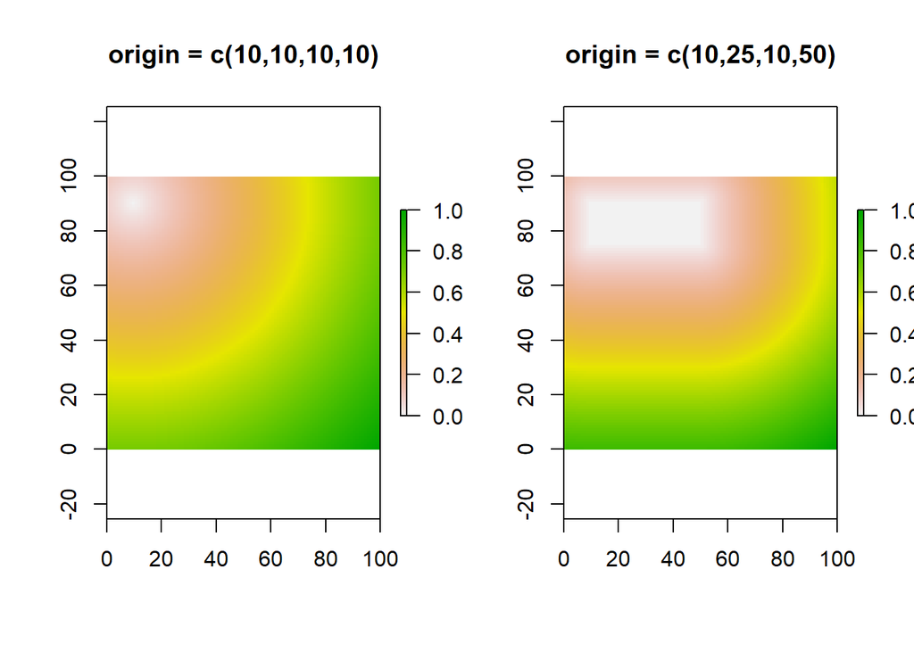

The edge gradient acts as a linear gradient oriented model in a given direction with a central peak. Application unknown?

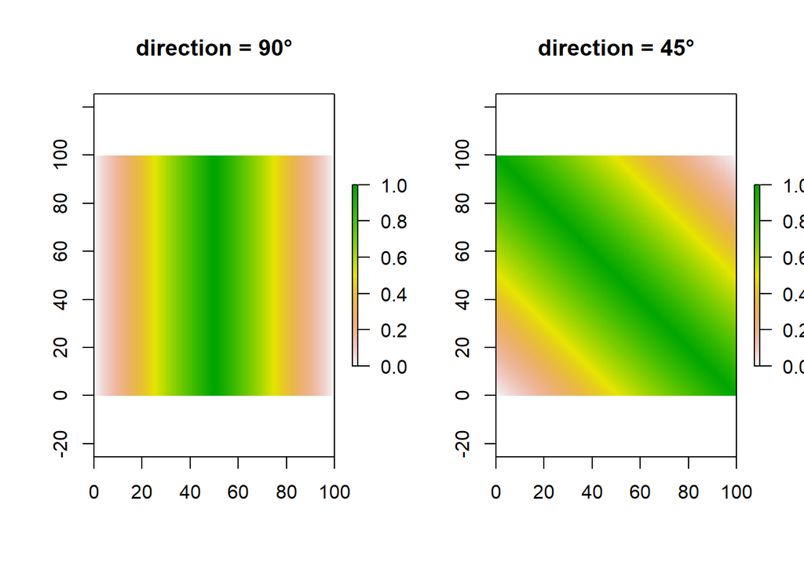

The planar gradient acts as a linear slope oriented model in a given direction. This type of gradient could represent a smooth homogenous change in environmental variable.

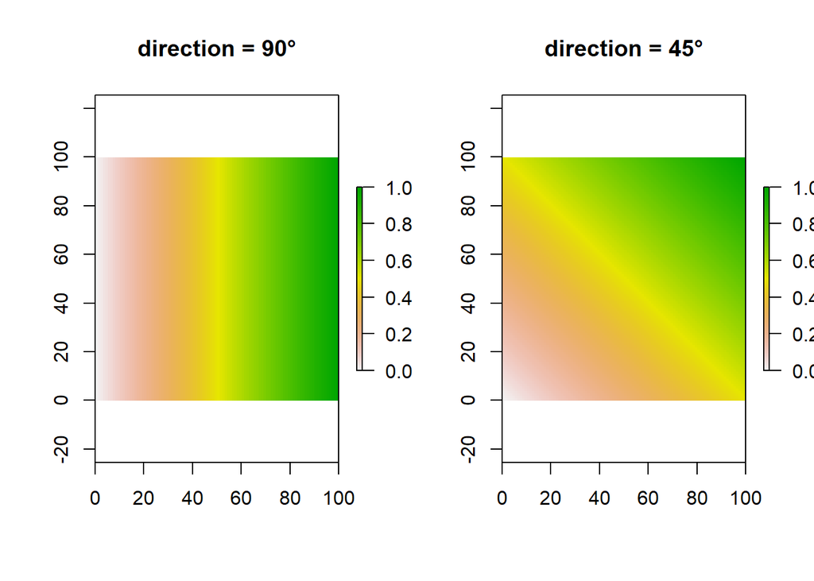

### 1.2.1.2. patchiness simulation

NLMR includes multiple different models capable of simulating forms of patchiness : Random curdling, Fractional browninan motin, Gaussian random field, Mosaic random field, Random neighborhood, Percolation, Polygonal landscapes (tesselation and gibbs), Random cluster, Midpoint displacement, Random rectangular cluster and Wheyed random curdling.

the most interesting ones appear to be: - Random curdling  
- Fractional brownian motion | Gaussian random field | Midpoint displacement (similar?) - Random neighborhood - Random cluster

The random curdling model subdivides the landscape into randomized incremental blocks, where percent cover of habitat are randomly distributed at each incremental scale. Curds are the % cover of habitat, recusion steps is the number of blocks withing the next previous block level, and wheyes is an additionnal habitat fill (?). Binary, but interesting for hierarchical organization.

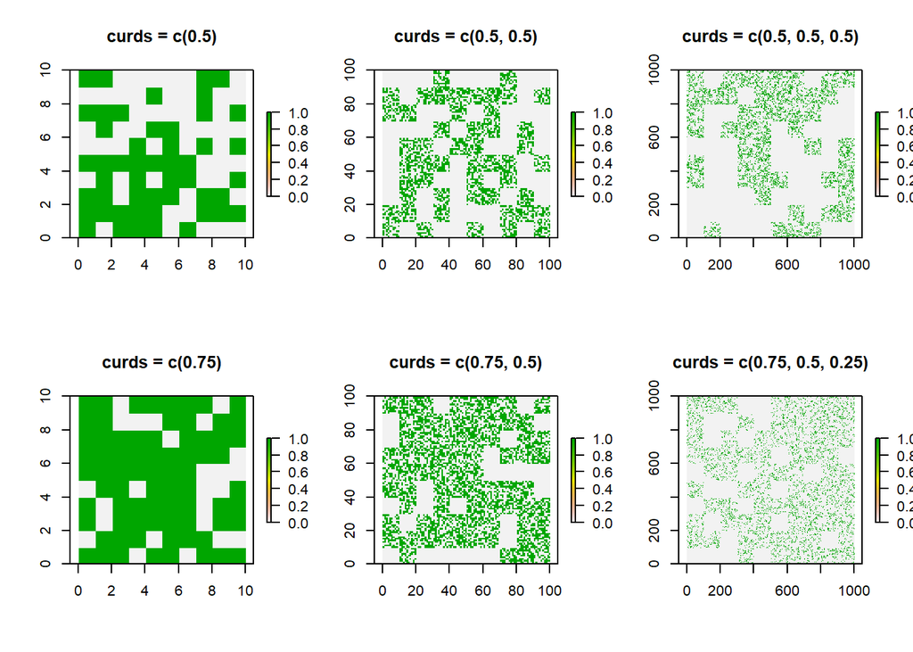

From the documentation, Fractional brownian motion, Gaussian random field & Midpoint displacement all seem to create a similar kind of landscape. For Fractional brownian Motion, fractal dimention is the main driver in landscape variations, being related to autocorrelation within the landscape. Good for basic autocorrelation driven patches.

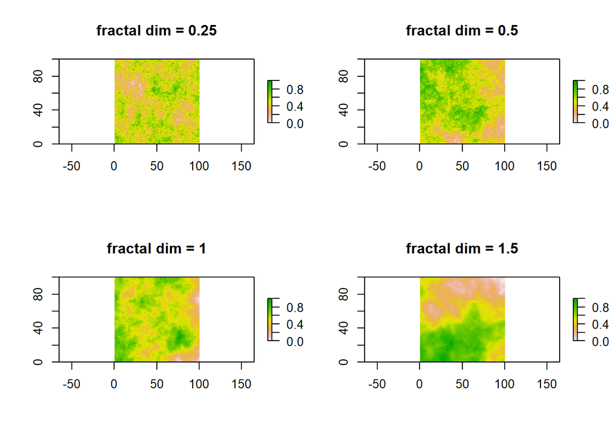

Gaussian random field uses autocorrelation range and magnitude terms as the landscape and autocorrelation scales. similar to browninan movement but with more control over certain parameters.

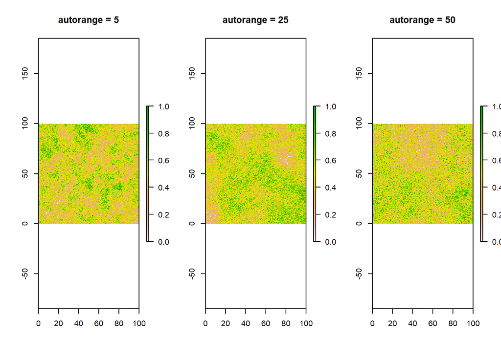

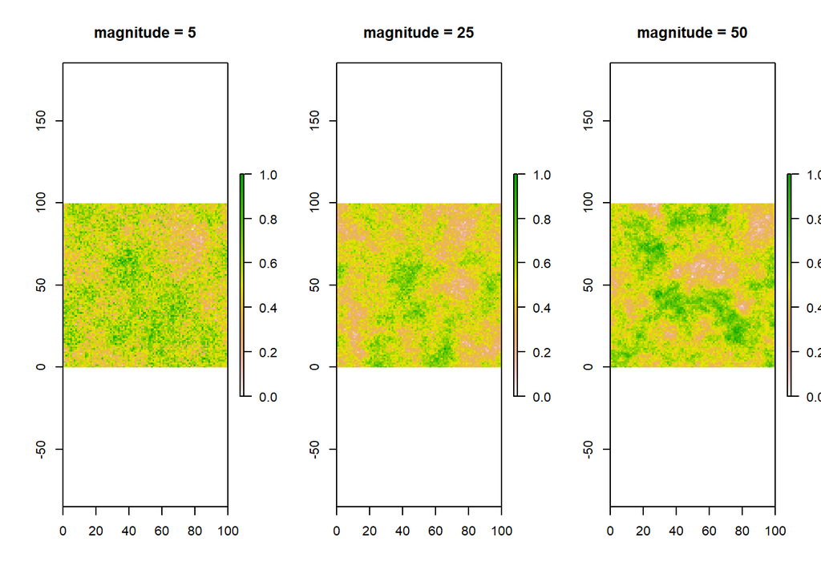

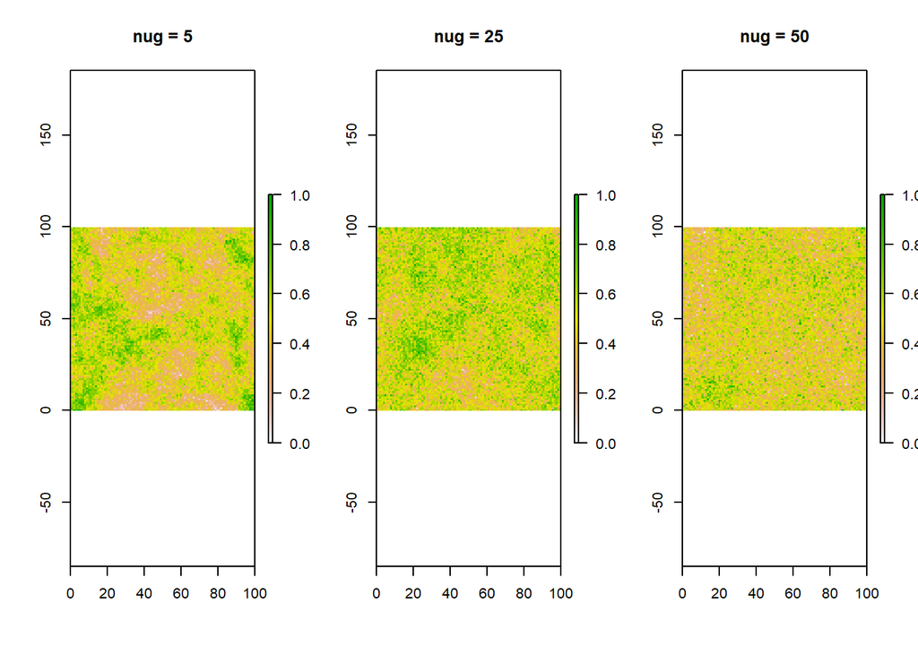

Midpoint displacement: hard to understand, but most of the changes come from the roughness parameter. small effect of random deviation and torus arguments.

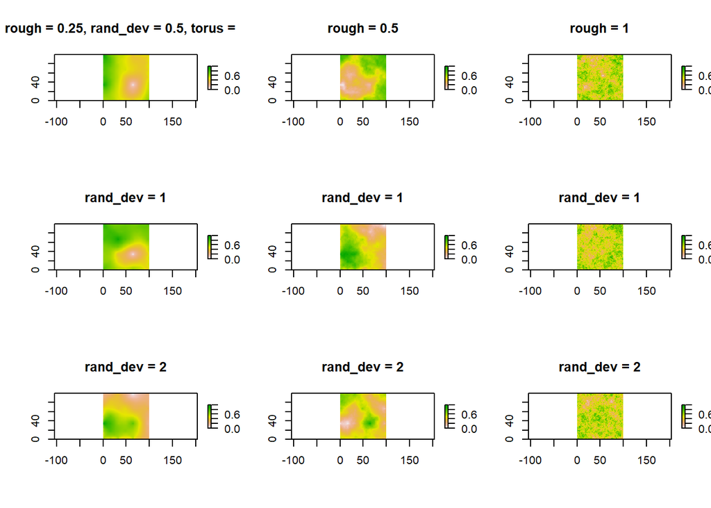

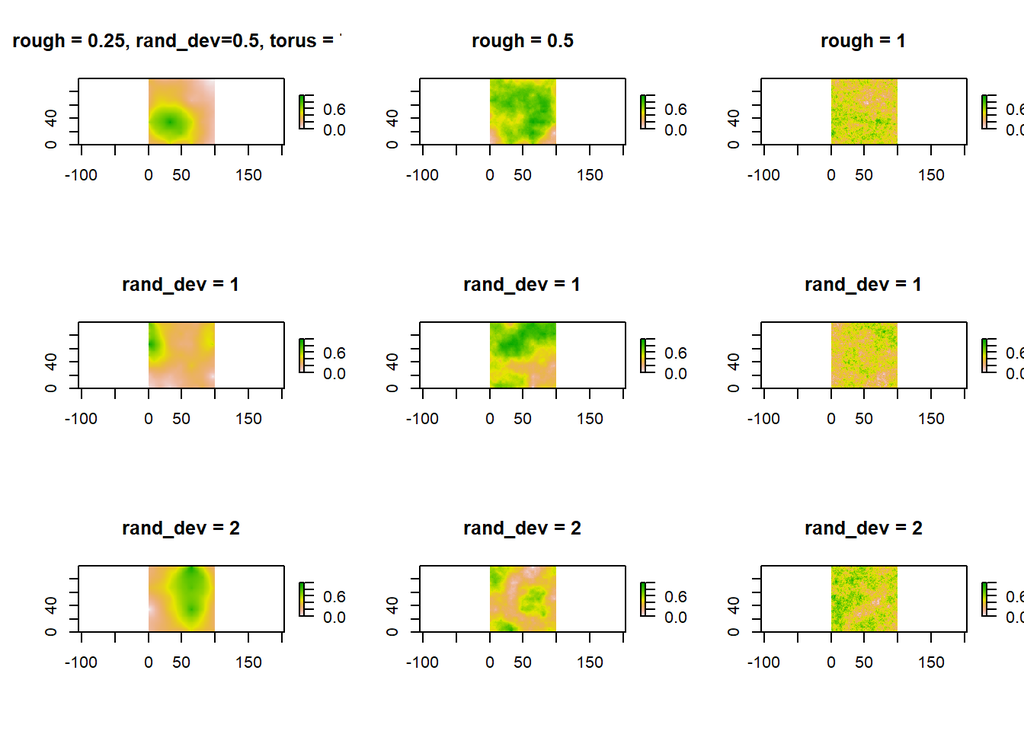

random neighborhors appears usefull for creating multiple interacting classes within a landscape

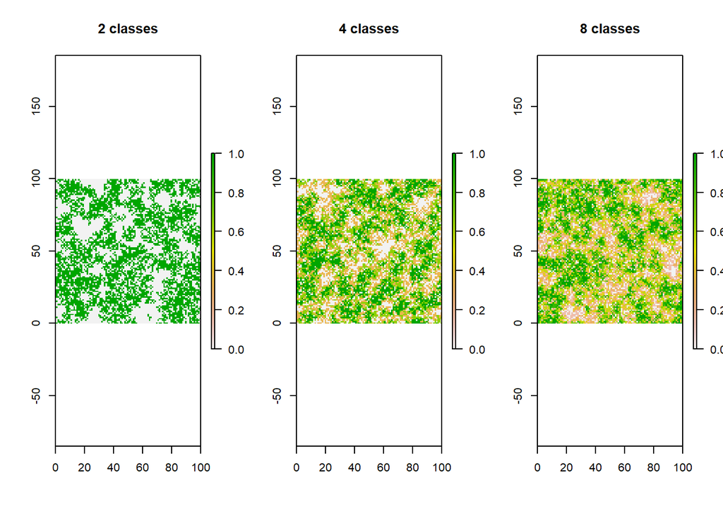

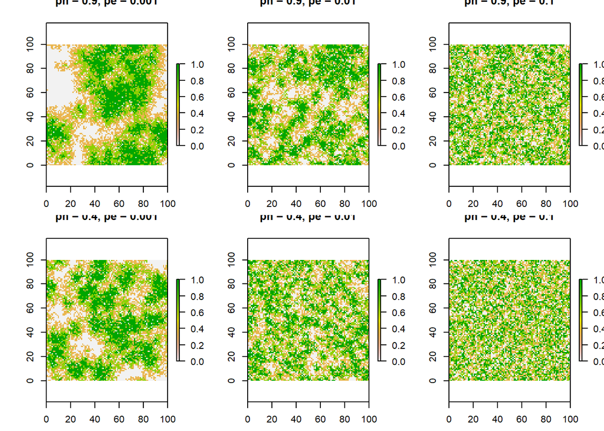

random cluster creates multiples classes of clusters (number and proportion dictated by ai parameter) according to a parameter p that defines how much of those classes will be in a single cluster. the result is relatively simple random patches

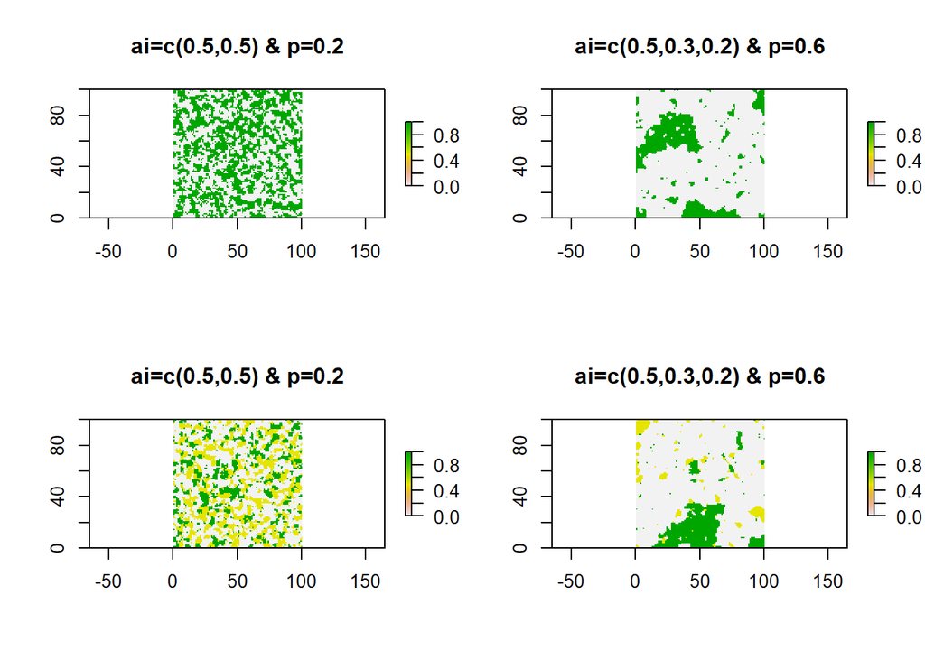

### 1.2.1.3. spatial noise simulation

NLMR includes two different models capable of simulating random noise: a random one and a percolation random model.

The random model is just completely random

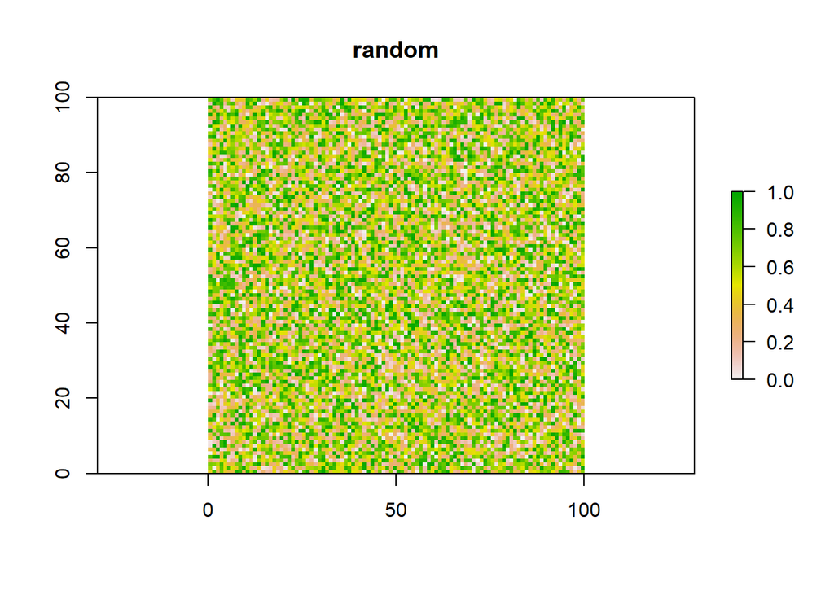

But the percolation model is random based on a designated proportion

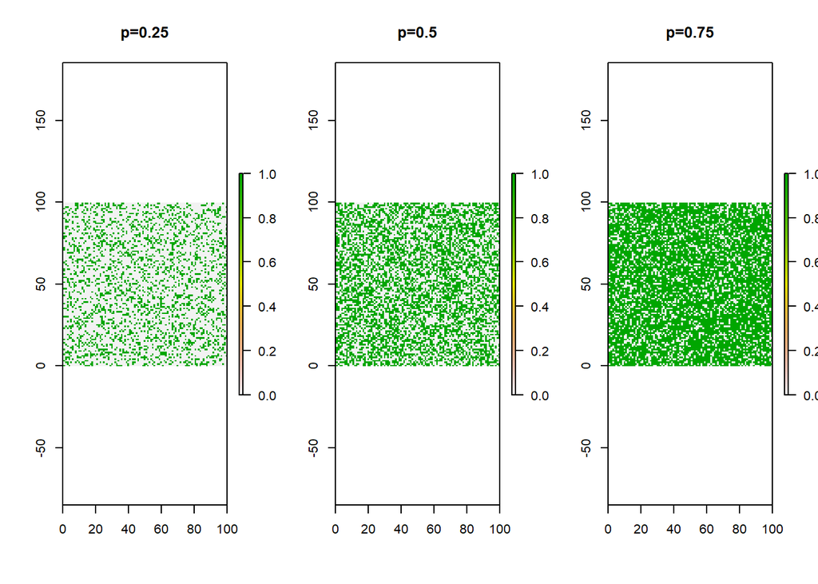

### 1.2.1.4. Composite landscape model

Let’s generate a landscape similar to a natural one expressing a single vegetation index in the water, with 4 terms:  
1. vegetation, simulated with fractional brownian movement  
2. bathymetry (or depth), creating a directional distribution and signal gradient with a planar gradient  
3. random noise, associated with sensor quality  
4. percolation noise, simulating waves effect

```
##           used (Mb) gc trigger (Mb) max used  (Mb)
## Ncells 1538497 82.2    2564207  137  2564207 137.0
## Vcells 2287965 17.5   12570278   96 10820065  82.6
```

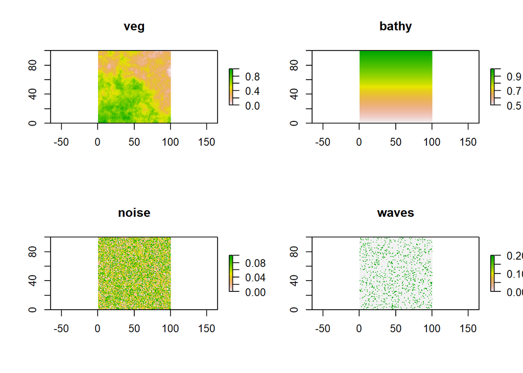

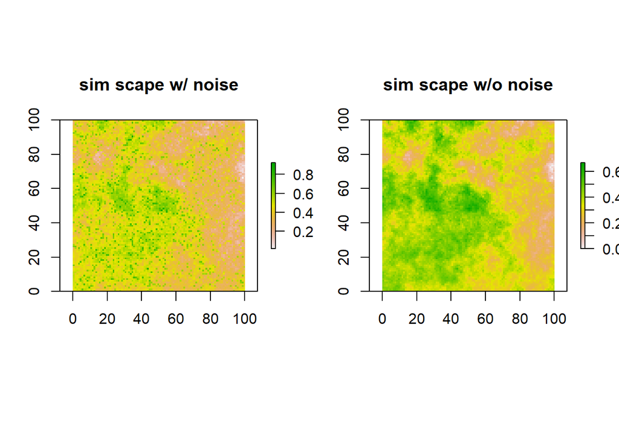